# Effects of forest conditions on the Pacific giant salamander

Anthony Luna and Elliott Matthews

11/30/2019

## Introduction

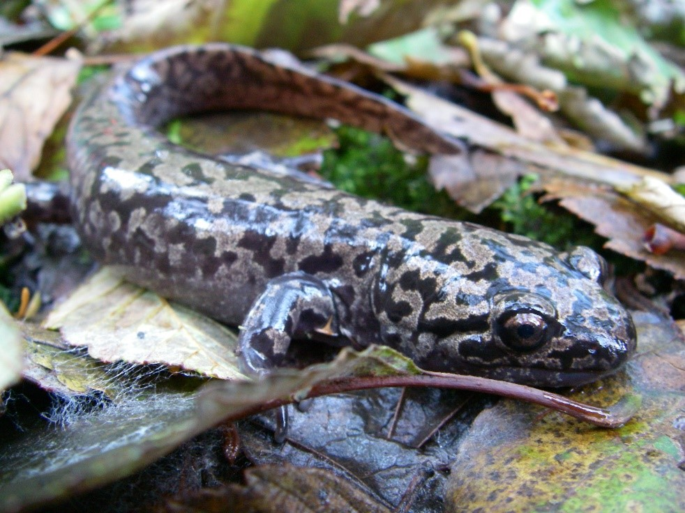

**Figure 1:**Pacific Giant Salamander (*Dicamptodon tenebrosus*) in its natural habitat. Credit: [Wikimedia Commons, the free media repository. 12/3/19](https://commons.wikimedia.org/w/index.php?title=File:Dicamptodon_tenebrosus_2.JPG&oldid=354477061)

## Data and Methods

Provided by Andrews Forest LTER Site, the weight and abundance data are part of an aquatic vertebrate population study and monitoring program conducted by Oregon State University. Though the program’s inception dates back to 1987, Pacific Giant Salamanders have only been monitored since 1993 [2]. Initial analysis entails, salamander population counts grouped annually based on the type of forest section (old growth or clear cut) they were observed and is visualized via line graph. Next the scope narrows to salamanders observed in 2017 in order to construct a table illustrating salamander catch location (cascades, pool, side channel) that reflects relative percentage to total population of old growth and clear-cut forest sections along Mack Creek. A chi-square test was then performed for insight about forest condition and its potential effect on salamander location. Mean weights are grouped by forest condition and catch location and then compared via two sample t-test (Welch’s t-test, $\alpha = 0.05$) and ANOVA ($\alpha = 0.05$). Means are also compared by the effect size (Cohen’s d, $\alpha = 0.05$) for both forest condition and channel classification. Weight distributions and mean weights of the salamanders are visualized with a violin plot by channel classification. All analyses and figures were prepared using R software version 3.6.1.

## Results

#### Annual salamander counts in old growth vs clear cut forests.

Over the majority of years observed, old growth salamander populations exceed clear cut forest populations. The exceptions to this are seen in 1993 and 1994 at the start of data collection as well as from 2015 to 2017 samples where clear cut salamanders exhibit higher counts.Additionally, the plots mirror each other’s general trend. In other words, an increase in one population for a given year typically saw a similar response by the other population.

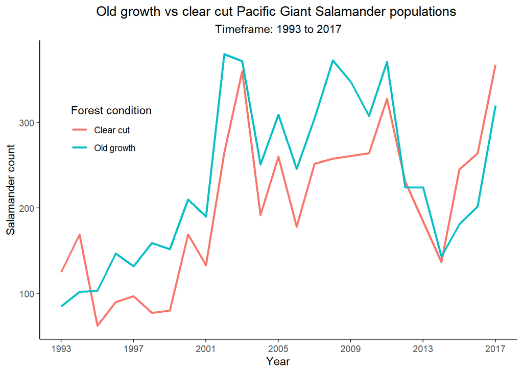

**Figure 3**: Old growth and clear cut regional populations tend to vary similarly, however the clear cut population is generally lower than the old growth populations.

#### Pacific giant salamander population distributions in 2017

Next, 2017 salamander counts grouped by catch location were analyzed and demonstrated that in both clear cut and old growth forest sections, cascades hold the majority of salamander populations followed by side channels and pools respectively. The results presented in Table 1 were then further examined using a chi squared test to determine if forest condition had a significant effect on salamander catch location. No significant association was found through testing (chi-square test, p = 0.063)

Table 1: Salamander count by location found in channel (2017)

| Forest condition | Cascades | Pool | Side channel |
| --- | --- | --- | --- |
| Clear cut | 247 (67.1%) | 31 (8.4%) | 90 (24.5%) |
| Old growth | 201 (62.8%) | 45 (14.1%) | 74 (23.1%) |

#### Comparison of weights of Pacific giant salamanders in 2017.

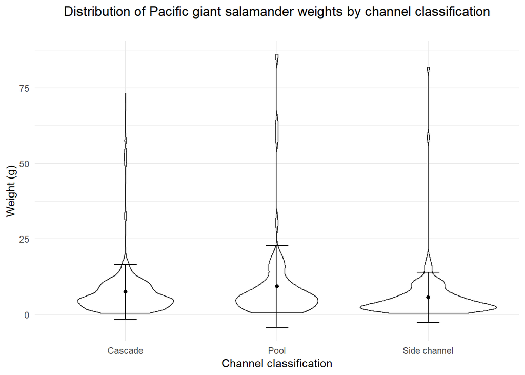

**Figure 4**: Comparison of the distribution and mean values of the Pacific giant salamander in each channel classification. widely varying distributions are seen. The points on each section show the channel classification mean weight, and the error bars signify 1 standard deviation from the mean.

When considering mean weight differences by channel classification, an analysis of variance shows a statistically significant difference between mean weights of salamanders (p = 0.015). A pairwise comparison of the effective size (Cohen’s d) was found to be negligible when comparing cascades and pools (d = -0.181), and small when comparing side channels to pools (d = 0.353), and side channels to cascades (d = 0.209). Despite this statistical difference, it is difficult to determine which channel classifications have differences without post-hoc testing. Further analysis using a pairwise comparison of channel classifications, such as Tukey’s Honest Significant Difference, could be used to determine which groups exhibit statistically significant differences.

## References

[1] HJ Andrews Experimental Forest LTER, “History,” H.J. Andrews Experimental Forest - Oregon State University, 20-Jan-2017. [Online]. Available: https://andrewsforest.oregonstate.edu/about/history. [Accessed: 02-Dec-2019].

[2] Gregory S. V., “Aquatic Vertebrate Population Study in Mack Creek, Andrews Experimental Forest, 1987 to present.” 2016. Environmental Data Initiative. https://doi.org/10.6073/pasta/5de64af9c11579266ef20da2ff32f702. [Accessed: 11/19/2019].

[3] E. Heaston, M. Kaylor, and D. Warren, “Characterizing short-term light dynamics in forested headwater streams,” Freshwater Science, vol. 36, pp. 000–000, 2017.